# zooaRchGUI User Manual

### **9. Multivariate Statistics Menu**

#### 9.1 D-Matrices

##### D-Matrices

[figure not shown]

This function will calculate the distance function of the selected data. It will accept dataframes already in R memory or loaded by the user. The methods that the distance can be calculated are: Canberra, Euclidean, Jaccard, and Manhattan. The variables that the distance between will calculated are selected by the user. The output will be saved as a distance matrix as “D_Matrix_Results”.

#### 9.2 Hotelling T-Tests

##### One Sample

This function is currently unavailable.

##### Two Sample*

[figure not shown]

#### 9.3 MANOVA

##### MANOVA

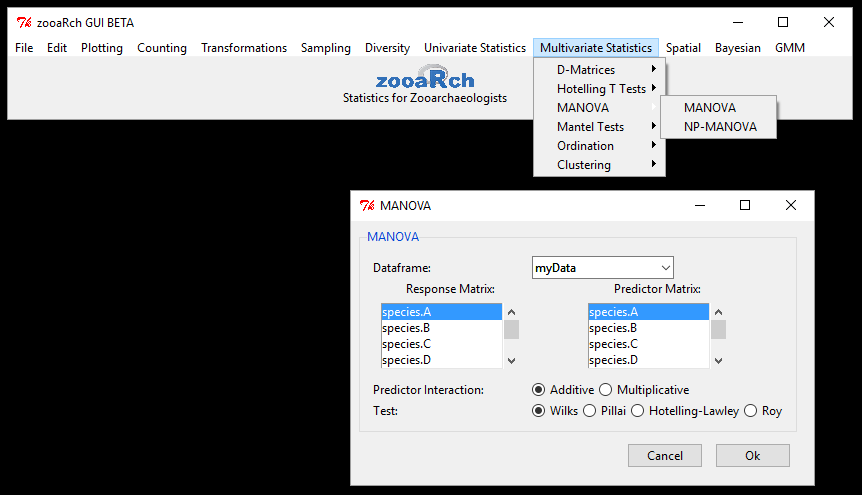

This function will perform a MANOVA on the selected dataset. It will accept dataframes already in R memory or loaded by the user. The response and predictor variables are chosen using the “Response” and “Predictor” comboboxes respectively. The interactions between the two variables can either be additive or multiplicative. The test that will be conducted can be the Wilks, Pillai, Hotelling-Lawley, Roy. The results are printed in the console and saved in R memory as “Results”.

##### NP-MANOVA

[figure not shown]

This function will perform a NP-MANOVA on the selected dataset. It will accept dataframes already in R memory or loaded by the user. The response and predictor variables are chosen using the “Response” and “Predictor” comboboxes respectively. The interactions between the two variables can either be additive or multiplicative. The methods that will be used to find the distance can be the Canberra, Euclidean, Jaccard, or Manhattan. The number of permutations that is selected using the “Permutations” slider. The results are printed in the console and saved in R memory as “Results”.

#### 9.4 Mantel Tests

##### 2-way Mantel*

This function will perform a 2-way Mantel test on the selected datasets. It will accept dataframes already in R memory or loaded by the user. The selected dataframes cannot contain missing values or characters. This function requires two dataframes that will be selected using their respective comboboxes. The columns that the test will be conducted on are selected using the listboxes that correspond to each of the dataframes. Multiple columns can be selected from each listbox. The distance method for each of the datasets can be either Canberra, Euclidean, Jaccard, or Manhattan. The number of permutations for the test is selected using the “Permutations” slider. The results will be printed in the console and saved in R memory as “Results”.

##### 3-way Mantel

[figure not shown]

This function will perform a 3-way Mantel test on the selected datasets. It will accept dataframes already in R memory or loaded by the user. The selected dataframes cannot contain missing values or characters. This function requires three dataframes that will be selected using their respective comboboxes. The columns that the test will be conducted on are selected using the listboxes that correspond to each of the dataframes. Multiple columns can be selected from each listbox. The distance method for each of the datasets can be either Canberra, Euclidean, Jaccard, or Manhattan. The number of permutations for the test is selected using the “Permutations” slider. The results will be printed in the console and saved in R memory as “Results”.

#### 9.5 Ordinations

##### Seriation

This function is currently unavailable.

##### PCA

[figure not shown]

This function will perform a PCA test on the selected dataset. It will accept dataframes already in R memory or loaded by the user. The selected dataframe cannot contain missing values or characters. The columns that the test will be performed on are selected using the “Choose Data” listbox. Multiple columns can be selected from the dataset. The results can be plotted if the “plot data” checkbox is marked. The results will be printed in the console and saved in R memory as “Results”.

##### PCoA

[figure not shown]

This function will perform a principle coordinate analysis on the selected dataset. It will accept dataframes already in R memory or loaded by the user. The selected dataframe cannot contain missing values or characters. The distance method that will be used for the analysis can be either Canberra, Euclidean, Jaccard, or Manhattan. The columns that will be used are selected using the “Choose Data” listbox. Multiple columns can be selected from the dataset. The results of the analysis are plotted and printed in the console. They are also saved in R memory as “PCoA_Results”.

##### NMDS

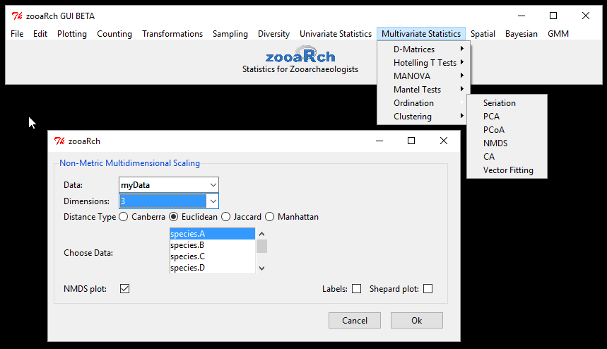

This function will perform a non-metric multidimensional scaling analysis on the selected dataset. It will accept dataframes already in R memory or loaded by the user. The selected dataset cannot contain missing values or characters. The number of dimensions that the analysis will be conducted in is selected using the “Dimensions” combobox. The method that the distance will be calculated in can be either Canberra, Euclidean, Jaccard, or Manhattan. The columns that the analysis will be conducted on are chosen using the “Choose Data” listbox. Multiple columns can be chosen from the dataset. A NMDS plot will be created if the “NMDS plot” checkbox is marked. The plot will contain labels if the “Labels” checkbox is marked. A Shepard plot will be created if the “Shepard plot” checkbox is marked.

##### CA

[figure not shown]

This function will perform a correspondence analysis on the selected dataset. It will accept dataframes already in R memory or loaded by the user. The selected dataset must not contain missing values or characters. The columns that will be used in the analysis are selected using the “Choose Data” listbox. The results can be plotted if the “plot data” checkbox is marked. The results of the analysis are printed in the console and saved in R memory as “Results”.

##### Vector Fitting

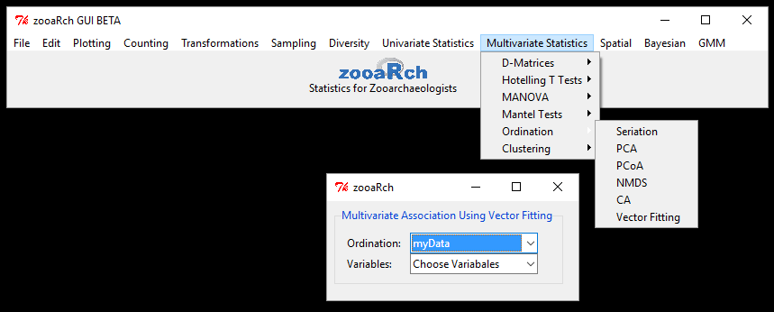

#### 9.6 Clustering

##### Hierarchical

[figure not shown]

This function will perform various hierarchical clustering methods on the selected dataset. It will accept distance matrices from the R memory or loaded by the user. The clustering method can be either Single linkage, Complete linkage, Average linkage, Centroid linkage, Mcquitty, Median linkage, Ward’s method, or Ward’s 2. The results are plotted.

##### K-means

###### **Single K-means**

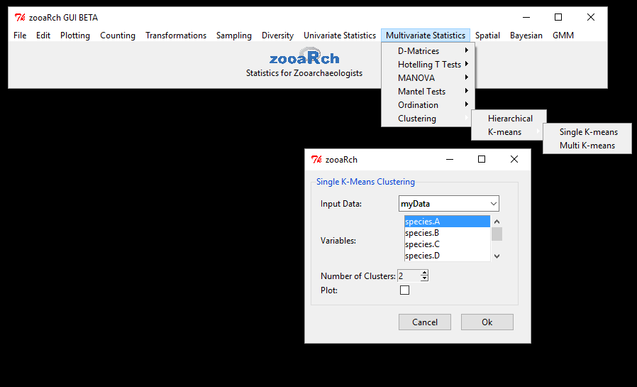

This function will perform K-means clustering using simplified parameters. It will accept distance matrices from the R memory or loaded by the user. The selected dataset cannot contain missing values or characters. The columns that will be used are selected using the “Variables” listbox. Multiple columns can be chosen from the dataset. The number of clusters can be chosen using the “Number of Clusters” spinbox. The results can be plotted if the “Plot” checkbox is marked. The results saved in R memory as “SingleKmeans”.

###### **Multiple K-means**

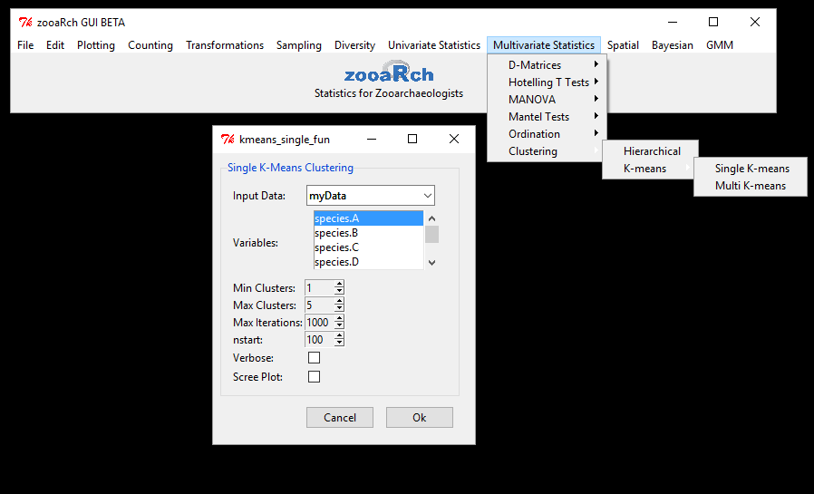

This function will perform K-means clustering using user-inputted parameters. It will accept distance matrices from the R memory or loaded by the user. The dataset cannot contain missing values or characters. The columns that will be used are selected using the “Variables” listbox. Multiple columns can be chosen from the dataset. The minimum and maximum number of clusters can be chosen by the “Min Clusters” and “Max Clusters” spinboxes respectively. The Max number of iterations and the number of random sets that can be chosen are selected by the “Max Iterations” and “nstart” spinboxes respectively. The function will be run verbose if the “Verbose” checkbox is marked. A Scree plot will be created if the “Scree Plot” checkbox is marked. The results will be saved in R memory as “MultiKmeans”.

### **10. Spatial Statistics Menu**

#### 10.1 Point Patterns

##### Ripley’s K

[figure not shown]

This function will perform a Ripley’s K analysis on the selected dataset. It will accept dataframes already in R memory or loaded by the user. It will also accept shapefiles loaded by the user. The shape of the boundary box of the Ripley’s K function can be loaded as a shapefile by selecting the “Load” option. The loaded shapefile cannot contain more than one polygon. The boundary shape can also be a custom draw figure if the “Custom” option is selected. With the custom shape a figure will appear on the console. The user will select the vertices of the shape that they wish to create. When the shape is complete the user will click finish to create the shape. The number of bins that the Ripley’s K function will use is selected using the “Bins” slider. The number of permutations used is determined by the “Permutations” slider. The results of the function will be plotted and printed in the console.

#### 10.2 Spatial Connections

##### Spatially Defined Connections

[figure not shown]

This function will find spatially defined connections in the selected dataset. It will accept spatial polygon dataframes from the R memory or loaded by the user. It will also accept shapefiles loaded by the user. The spatially defined connections can be found using the Queen, Rook, Delauney, Gabriel, or Relative methods. The voroni data can be plotted if the “Voroni data” checkbox is marked. The results of the function are plotted.

#### 10.3 Autocorrelation Tests

##### Global Moran’s I/Geary C

[figure not shown]

This function will perform a Global Moran’s I or Geary C test. It will accept spatial polygon dataframes from the R memory or loaded by the user. It will also accept shapefiles loaded by the user. The input variable is a list in the loaded file that the test will be conducted with. The display title will be the title of the created plot. The method that the test will use is either Moran’s I or Geary C. The number of bins is determined by the “Number of Bins” slider. The results of the test are plotted.

##### LISA

This function is currently unavailable.

##### Getis ORD GI*

This function is currently unavailable.

#### 10.4 Variogram Modeling

##### Plot Spatial Covariance

This function is currently unavailable.

##### Plot Spatial Semi-Variogram

This function is currently unavailable.

##### Fit Semi-Variogram

This function is currently unavailable.

#### 10.5 Interpolation

##### Kriging

This function is currently unavailable.

##### TPS

This function is currently unavailable.

##### IDW

This function is currently unavailable.

### **11. Bayesian Statistics Menu**

#### 11.1 Bayesian Tests

##### Bayesian 1 sample t-test

[figure not shown]

This function will perform a Bayesian one sample t-test using the selected data. It will accept dataframes already in R memory or loaded by the user. The column that the test will be performed with is selected using the “Variable” combobox. The Mu value the number in the “Mu” entrybox. The credible interval level is determined by the “cred.mass” slider. The results are printed in the console and saved in R memory as “Results”.

##### Bayesian 2 sample t-test

[figure not shown]

This function will perform a Bayesian two sample t-test using the selected data. It will accept dataframes already in R memory or loaded by the user. The two columns that will be performed with is selected using the “Variable 1” and “Variable 2” comboboxes respectively. The credible interval is determined by the “cred.mass” slider. The test will be performed as a paired test if the “paired” checkbox is marked. The results are printed in the console and saved in R memory as “Results”.

##### Bayesian Binomial Test

[figure not shown]

This function will perform a Bayesian Binomial test on the selected data. The number of successes and trials that will be performed based on the values in the “Successes” and “Trials” entryboxes. The composition proportion is the value in the “Comp prop” entrybox. The credible interval is determined by the “cred.mass” slider. The results of the test are printed in the console and saved in R memory as “Results”.

### **12. Geometric Morphometrics Menu**

#### 12.1 Import Data

[figure not shown]

This function will import .tps .nts, or multiple .nts files. The imported data will be saved as an array with the name of the original file in R memory unless the multi.nts option is chosen. Then the data will be saved in R memory as “collective.array”.

#### 12.2 Digitize

##### 2D-Digitize

This function is currently unavailable.

##### 3D-Digitize

This function is currently unavailable.

#### 12.3 GPA

[figure not shown]

This function will perform a gpagen analysis on the selected dataset. It will accept arrays from the R memory or loaded by the user. The curve and the surface arrays are selected from the R memory or loaded by the user. If “None” is selected, then there will be nothing inputted for those values. The type of test that is used is either the Prod, or Bending Energy. The progress is plotted if the “Plot Progress” checkbox is marked. The results of the test are printed in the console, plotted and saved in R memory as “gparesults”.

#### 12.4 Plot

##### Tangent Space

This function is currently unavailable.

##### Deformation

This function is currently unavailable.

##### Reference-Target Deformation

This function is currently unavailable.

##### Analysis

This function is currently unavailable.